# 03-Information-Hiding

The most important technique for achieving deep modules is information hiding. Each module encapsulates a few pieces of knowledge (data structures, algorithms, etc.) that represent design decisions. This knowledge is embedded in the implementation, but does not appear in the interface, so it is not visible to other modules.

The most common type of information hidden in a module is what we informally refer to as “implementation details”. For example:

- The implementation of a “dictionary” (could be a tree, a hash table, etc.)
- The details of a network protocol
- How to parse a given file format

The opposite of information hiding is *information leakage*. Information leakage occurs when a design decision is reflected in multiple modules, creating a dependency.

## Example: Exposing internal data structures

Consider the following classes to model courses, and students who register for a specific course offering, at a university. For simplicity, let's assume a course can only be offered once per year:

```python
class Course:
    code: int
    name: str

    def __init__(self, code: int, name: str):
        self.code = code
        self.name = name

class Student:
    name: str
    student_id: int

    def __init__(self, name: str, student_id: int):
        self.name = name
        self.id = student_id

class CourseOffering:
    course: Course
    year: int
    students: list[Student]

    def __init__(self, course: Course, year: int):
        self.course = course
        self.year = year
        self.students = []
```

```python
cs142 = Course("CMSC 14200", "Introduction to Computer Science II")

cs142_23 = CourseOffering(cs142, 2023)

s1 = Student("Alex", 111)
s2 = Student("Sam", 222)
s3 = Student("Jo", 333)
```

Adding students is very simple, we just need to append to the list of students:

```python
cs142_23.students.append(s1)
cs142_23.students.append(s2)
cs142_23.students.append(s3)
```

In the context of Python, this generates very little cognitive load (since we're presumably already comfortable with using lists), but it can cause an issue if, later on, we decide that we want to store students in a dictionary, so we can more easily access them via their ID:

```python
class Course:
    code: int
    name: str

    def __init__(self, code: int, name: str):
        self.code = code
        self.name = name

class Student:
    name: str
    student_id: int

    def __init__(self, name: str, student_id: int):
        self.name = name
        self.id = student_id

class CourseOffering:
    course: Course
    year: int
    students: dict[int, Student]

    def __init__(self, course: Course, year: int):
        self.course = course
        self.year = year
        self.students = {}
```

Any code that relied on the students lists will now break, and will have to be updated:

```python
cs142 = Course("CMSC 14200", "Introduction to Computer Science II")

cs142_23 = CourseOffering(cs142, 2023)

s1 = Student("Alex", 111)
s2 = Student("Sam", 222)
s3 = Student("Jo", 333)

cs142_23.students.append(s1)
cs142_23.students.append(s2)
cs142_23.students.append(s3)
```

```
---------------------------------------------------------------------------
AttributeError                            Traceback (most recent call last)
Cell In[5], line 9
      6 s2 = Student("Sam", 222)
      7 s3 = Student("Jo", 333)
----> 9 cs142_23.students.append(s1)
     10 cs142_23.students.append(s2)
     11 cs142_23.students.append(s3)

AttributeError: 'dict' object has no attribute 'append'
```

A better approach would have been to *hide* how the students are stored internally:

```python
class Course:
    code: int
    name: str

    def __init__(self, code: int, name: str):
        self.code = code
        self.name = name

class Student:
    name: str
    student_id: int

    def __init__(self, name: str, student_id: int):
        self.name = name
        self.id = student_id

class CourseOffering:
    course: Course
    year: int
    _students: list[Student]

    def __init__(self, course: Course, year: int):
        self.course = course
        self.year = year
        self._students = []

    def add_student(self, student: Student) -> None:
        self._students.append(student)
```

```python
cs142 = Course("CMSC 14200", "Introduction to Computer Science II")

cs142_23 = CourseOffering(cs142, 2023)

s1 = Student("Alex", 111)
s2 = Student("Sam", 222)
s3 = Student("Jo", 333)

cs142_23.add_student(s1)
cs142_23.add_student(s2)
cs142_23.add_student(s3)
```

Note how this also allows us to use type annotations, if we wanted to validate that only Student objects should be added to the list of students (which we would not be able to do if we just depended on if we had other programmers interact with the `students` list directly.

Now, let's say we change the implementation to use a dictionary. We have to update the `add_student` method in our code, but users of our code don't need to change anything.

```python
class Course:
    code: int
    name: str

    def __init__(self, code: int, name: str):
        self.code = code
        self.name = name

class Student:
    name: str
    student_id: int

    def __init__(self, name: str, student_id: int):
        self.name = name
        self.id = student_id

class CourseOffering:
    course: Course
    year: int
    _students: dict[int, Student]

    def __init__(self, course: Course, year: int):
        self.course = course
        self.year = year
        self._students = {}

    def add_student(self, student: Student) -> None:
        self._students[student.id] = student
```

```python
cs142 = Course("CMSC 14200", "Introduction to Computer Science II")

cs142_23 = CourseOffering(cs142, 2023)

s1 = Student("Alex", 111)
s2 = Student("Sam", 222)
s3 = Student("Jo", 333)

cs142_23.add_student(s1)
cs142_23.add_student(s2)
cs142_23.add_student(s3)
```

## Example: File Formats

Suppose we are implementing some chess software, that uses a text-based file format to represent chess boards. For example, this chess board:

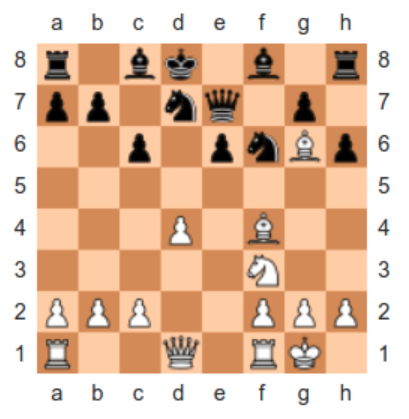

Would be represented as follows:

```
R_BK_B_R
PP_NQ_P_
__P_PNbP
________
___p_b__
_____n__
ppp__ppp
r__q_rk_
```

Each line represents a row of the chessboard. Empty spots are represented by an underscore character, black pieces are represented with uppercase letters, and white pieces are represented with lowercase letters:

- `p`/`P`: Pawn
- `r`/`R`: Rook
- `b`/`B`: Bishop
- `n`/`N`: Knight
- `q`/`Q`: Queen
- `k`/`K`: King

When writing our code, we could be tempted to do something like this:

```python
class Piece:
    char: str

    def __init__(self, char: str):
        self.char = char

    def is_white(self) -> bool:
        return self.char.islower()

    def is_black(self) -> bool:
        return self.char.isupper()

    def __str__(self) -> str:
        if self.char == "p" or self.char == "P":
            return "Pawn"
        elif self.char == "r" or self.char == "R":
            return "Rook"
        # etc.
```

This code is easy and convenient: we can iterate over the contents of the file and just pass the character in the file to the `Piece` constructor:

```python
p1 = Piece("R")
p2 = Piece("p")
```

```python
str(p1)
```

```
'Rook'
```

```python
p2.is_white()
```

```
True
```

```python
p2.is_black()
```

```
False
```

**Q**: What issues do you see with this design?

**A**: Suppose the file format changes; we either need to scrap our `Piece` class entirely or (even worse) add more code to our software to convert form the new file format to an old file format that is now just being used internally in our code.

Even if the file format doesn't change, what if we want to support multiple file formats? Once again, we'd have to add code to convert from other file format to an arbitrarily chosen format.

This design also has a high cognitive load: anyone using our `Piece` class would need to be familiar with the one-character representation for these chess pieces.

This is a different kind of information leakage: we're leaking information about a file format we are using. We *will* need to write code to deal with that file format, but information about that file format shouldn't leak outside of the code that reads in the files (and into the implementation of the `Piece` class itself)

A better solution (but which can still be improved) would be something like this:

```python
class Piece:

    PAWN = 0
    ROOK = 1
    BISHOP = 2
    KNIGHT = 3
    QUEEN = 4
    KING = 5

    WHITE = 0
    BLACK = 1

    piece_type: int
    color: int

    def __init__(self, piece_type: int, color: int):
        self.type = piece_type
        self.color = color
```

Creating pieces now looks like this:

```python
p1 = Piece(Piece.PAWN, Piece.WHITE)
```

The above style is pretty common, and your likely to encounter it in the wild, but a better approach would be to use "enums" ("enumerations"). Enums allow us to easily create a new type with a limited set of values. For example, the PieceColor type below can only take two values: `BLACK` or `WHITE`.

```python
from enum import Enum

class PieceColor(Enum):
    BLACK = 0
    WHITE = 1

class PieceType(Enum):
    PAWN = 0
    ROOK = 1
    BISHOP = 2
    KNIGHT = 3
    QUEEN = 4
    KING = 5

class Piece:

    piece_type: PieceType
    color: PieceColor

    def __init__(self, piece_type: PieceType, color: PieceColor):
        self.type = piece_type
        self.color = color
```

Creating pieces looks very similar:

```python
p1 = Piece(PieceType.PAWN, PieceColor.WHITE)
```

The main takeaway in both approaches is that we've decoupled the design of our `Piece` class from any particular file format, and the details of how to construct and use the `Piece` class don't require knowledge of any external file format.

Note: There is a more compact way of declaring enums that you'll see in some of the project code. For example, the enums shown above can be re-written like this:

```python
PieceColor = Enum("PieceColor", ["BLACK", "WHITE"])
PieceType = Enum("PieceType", ["PAWN", "ROOK", "BISHOP",
                               "KNIGHT", "QUEEN", "KING"])
```